# Wstęp do uczenia maszynowego - lab 1

Jakub Kosterna

February 25, 2020

# 1. Odczyt

```r
setwd("/home/samba/kosternaj/Desktop/06ML/bank")
data <- read.csv("bank.csv", sep = ';')
```

Zobaczmy czy wszystko poszło zgodnie z planem.

```r
library(DT)
datatable(data)
```

|  | age | job | marital | education | default | balance | housing | loan | contact | day | month | duration | campaign | pdays | previous | poutcome | y |
| --- | --- | --- | --- | --- | --- | --- | --- | --- | --- | --- | --- | --- | --- | --- | --- | --- | --- |
| 1 | 30 | unemployed | married | primary | no | 1787 | no | no | cellular | 19 | oct | 79 | 1 | -1 | 0 | unknown | no |
| 2 | 33 | services | married | secondary | no | 4789 | yes | yes | cellular | 11 | may | 220 | 1 | 339 | 4 | failure | no |
| 3 | 35 | management | single | tertiary | no | 1350 | yes | no | cellular | 16 | apr | 185 | 1 | 330 | 1 | failure | no |
| 4 | 30 | management | married | tertiary | no | 1476 | yes | yes | unknown | 3 | jun | 199 | 4 | -1 | 0 | unknown | no |
| 5 | 59 | blue-collar | married | secondary | no | 0 | yes | no | unknown | 5 | may | 226 | 1 | -1 | 0 | unknown | no |
| 6 | 35 | management | single | tertiary | no | 747 | no | no | cellular | 23 | feb | 141 | 2 | 176 | 3 | failure | no |
| 7 | 36 | self-employed | married | tertiary | no | 307 | yes | no | cellular | 14 | may | 341 | 1 | 330 | 2 | other | no |
| 8 | 39 | technician | married | secondary | no | 147 | yes | no | cellular | 6 | may | 151 | 2 | -1 | 0 | unknown | no |
| 9 | 41 | entrepreneur | married | tertiary | no | 221 | yes | no | unknown | 14 | may | 57 | 2 | -1 | 0 | unknown | no |
| 10 | 43 | services | married | primary | no | -88 | yes | yes | cellular | 17 | apr | 313 | 1 | 147 | 2 | failure | no |

[output cut: 4511 more lines]

Wiwat! Jest Ok

# 2. Analiza

## 2.1)

Przyjrzyjmy się kolumnie “duration” - czasu w sekundach ostatniej konsultacji. Wpierw zweryfikujmy rozkład zmiennej

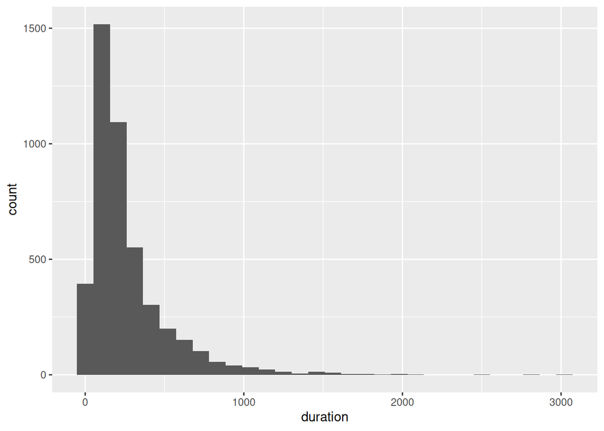

```r
library(ggplot2)
duration <- data$duration

ggplot(data, aes(x = duration)) +
  geom_histogram()
```

```r
print(paste("Mediana:", median(duration)))
```

```
## [1] "Mediana: 185"
```

```r
print(paste("Średnia:", mean(duration)))
```

```
## [1] "Średnia: 263.961291749613"
```

Jak widać przeważa czas trwania to kilku minut. Mediana to 3 minuty, a średnia niecałe 5. Rzadko kiedy rozmowa trwa dłużej niż 10 minut. Śladowy procent konsultacji przekroczył pół godziny. Ma sens? Ma.

## 2.2)

Może istnieje jakaś zależność między czasem rozmowy a wiekiem rozmówcy?

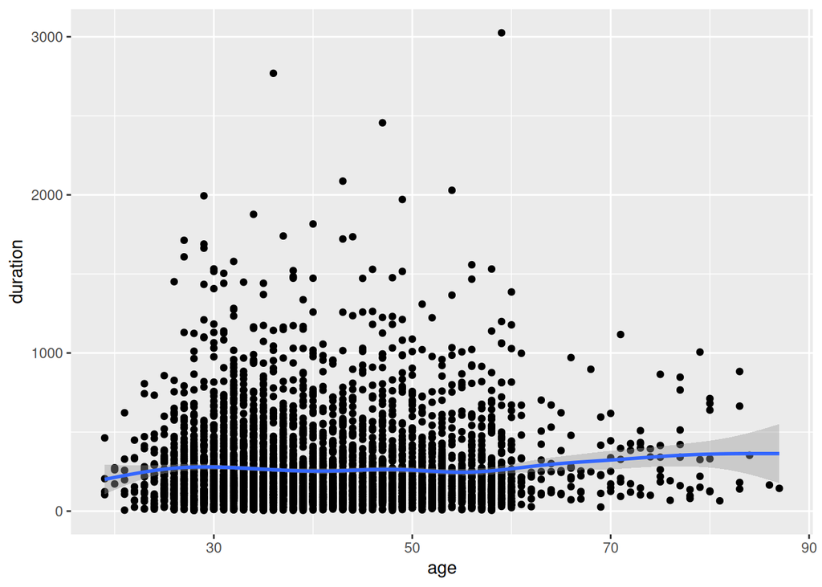

```r
ggplot(data, aes(x = age, y = duration)) +
  geom_point() +
  geom_smooth()
```

Chyba nic ciekawego. Co w kwestii stanu cywilnego?

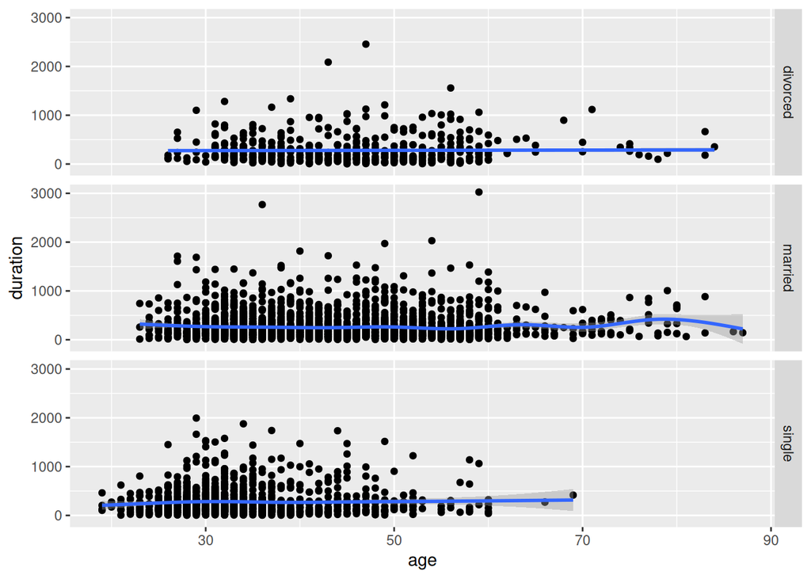

```r
ggplot(data, aes(x = age, y = duration)) +
  geom_point() +
  geom_smooth() +
  facet_grid(data$marital)
```

Tym bardziej nic ciekawego. Za wyjątkiem faktu, że żaden singiel po 70. się nie odezwał :O Mnie jeszcze ciekawi jak to będzie jeżeli weźmie się pod uwagę subskrypcję lokaty terminowej

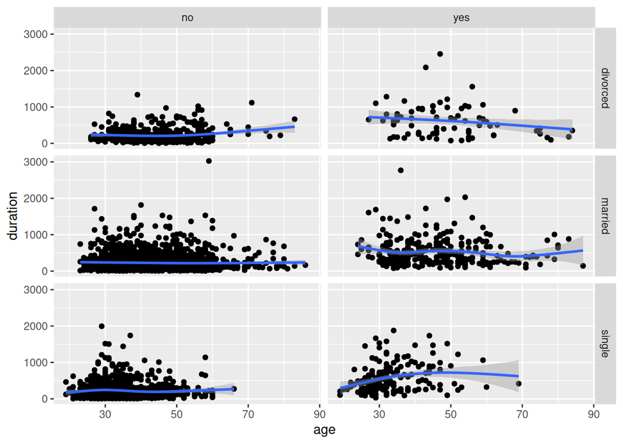

```r
ggplot(data, aes(x = age, y = duration)) +
  geom_point() +
  geom_smooth() +
  facet_grid(data$marital ~ data$y)
```

Rozwodnicy w zależności od subskrypcji z wiekiem gadają coraz krócej jeśli ją mają i coraz dłużej w przeciwnym wypadku? Niestety to chyba tylko kwestia małego zbioru danych. Ale może dla większego zbioru…

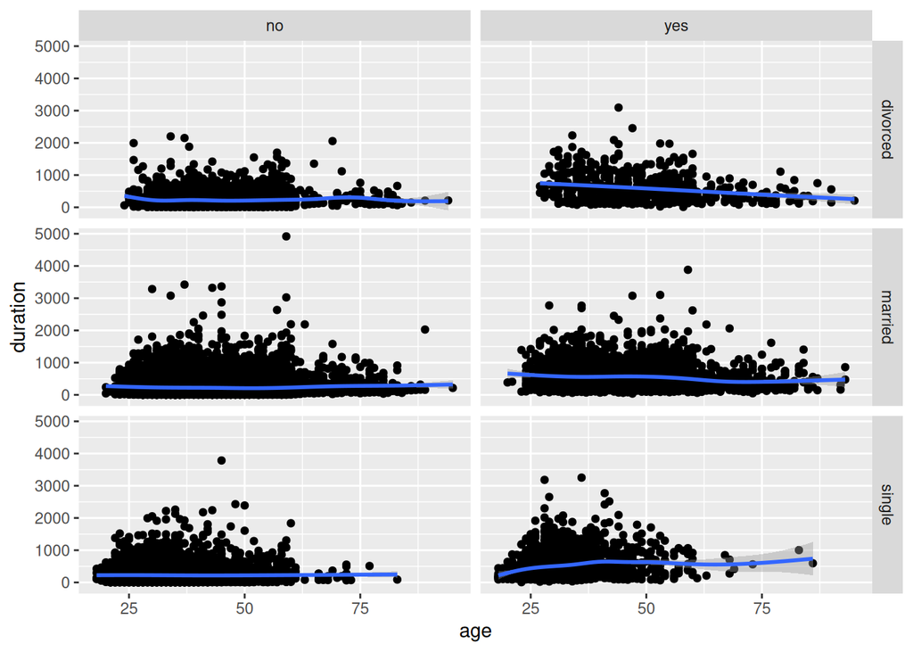

```r
dataFull <- read.csv("bank-full.csv", sep = ';')

ggplot(dataFull, aes(x = age, y = duration)) +
  geom_point() +
  geom_smooth() +
  facet_grid(dataFull$marital ~ dataFull$y)
```

Analiza większego zbioru danych wykazała, że tak jak dla nie-subskrybentów zależności nie ma… to subskrybujący rozwodnicy z wiekiem gadają coraz krócej, a subskrybujący single - coraz dłużej! Czyli samotni z wiekiem potrzebują więcej i więcej drugiego człowieka, a rozwodnicy mają go coraz bardziej dość - znowu bez zaskoczeń

Kolumna *campaign* mówi nam o liczbie wszystkich konsultacji danego klienta. Sprawdźmy czy ci którzy ostatni przeprowadzili dłuższą rozmowę, częściej komunikują się z firmą.

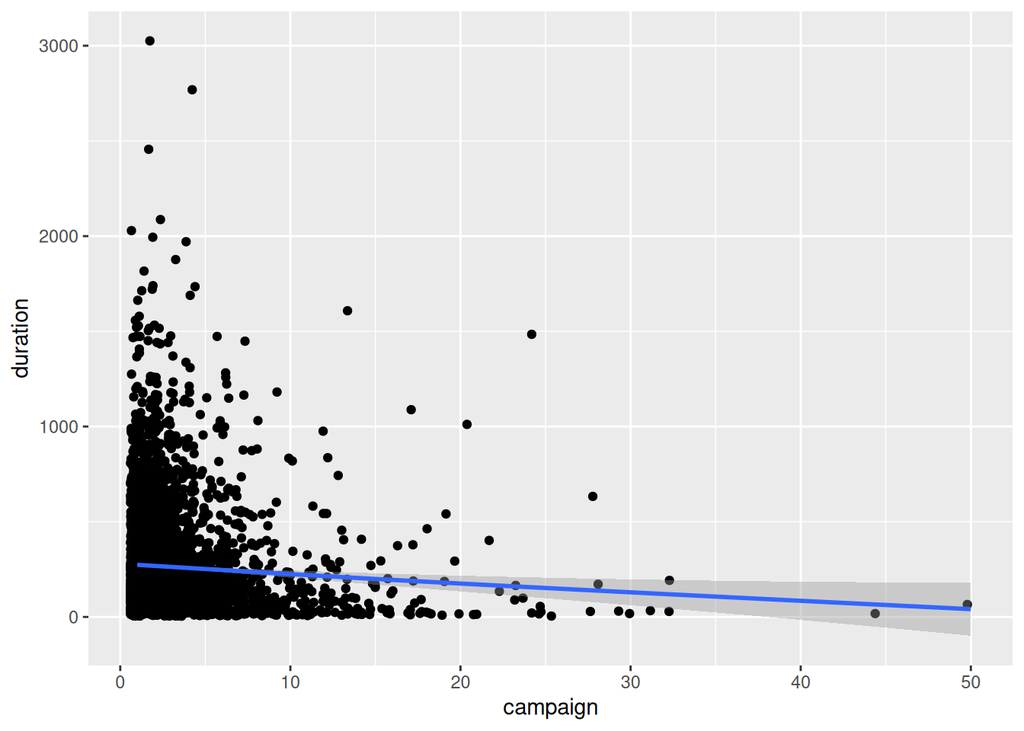

```r
ggplot(data, aes(x = campaign, y = duration)) +
  geom_jitter() +
  geom_smooth()
```

geom_smooth mówi że delikatnie więcej konsultacji <-> krótsza ostatnia rozmowa, ale w sumie kwestia sekund, więc… Weźmy jeszcze pod uwagę stan cywilny

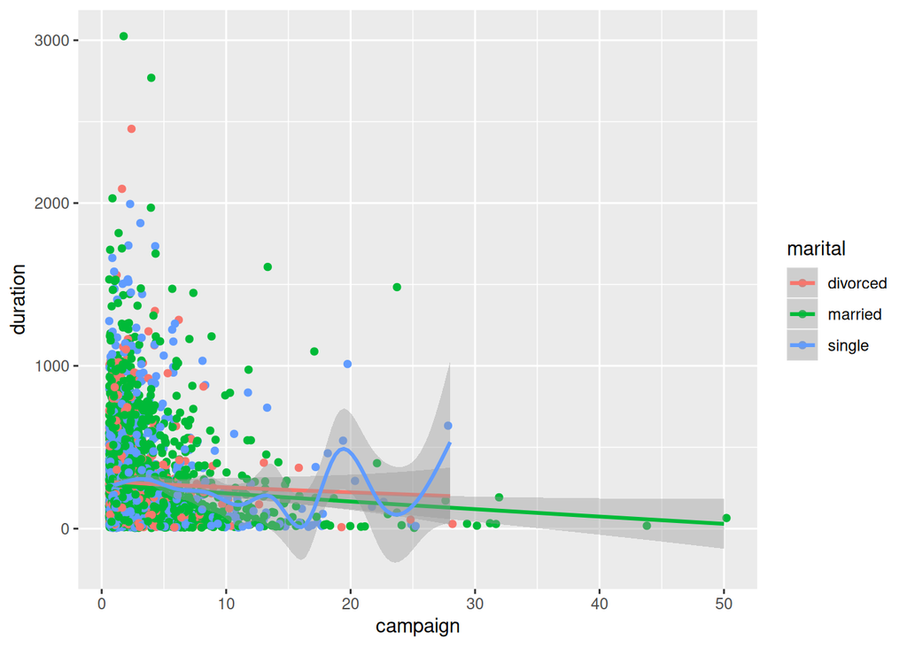

```r
ggplot(data, aes(x = campaign, y = duration, color = marital)) +
  geom_jitter() +
  geom_smooth()
```

Z singlami jest coś nie tak. Sprawdźmy duży zbiór danych.

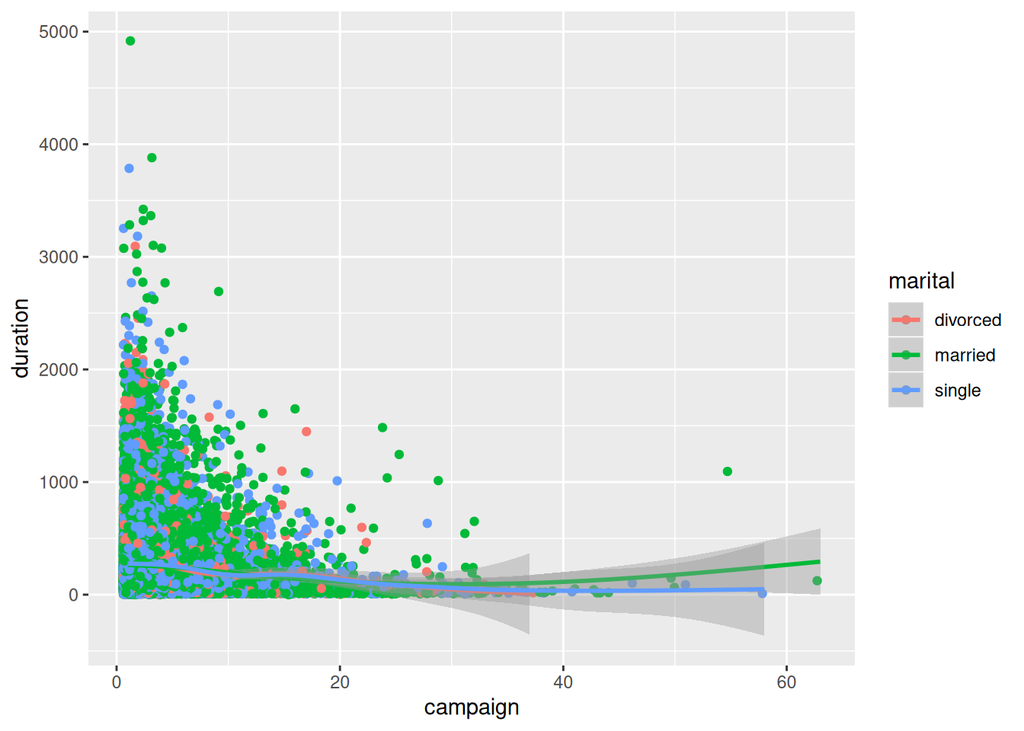

```r
ggplot(dataFull, aes(x = campaign, y = duration, color = marital)) +
  geom_jitter() +
  geom_smooth()
```

… jak widać geom_smooth() potrafi zaszaleć dla zbyt małego zbioru. Im więcej danych, tym daleko idące wnioski z przypadku ubogiego zbioru idą w zapomnienie :-(